# Long table with different group classifications

Erik Ø. Sørensen

2025-07-30

# Creating main table of results

The construction of the input data is pushed into the *target* `all`. What is needed is to present this in the shape we want.

Now, trying to put together a table with the outputs. I want to piece it together by groups of 4 columns (with optional counts), conditional on a partition of individuals, and conditional on a significance level. I also want to have an optional “header” column with number of observations.

## Code for constructing table of numbers

The construction is such that at the bottom level, `main_section` creates a short collection of cells, `main_row` collects a number of sections into a row, and `main_rows` creates all the necessary rows.

```r
main_section <- function(df, partition, alpha, ns=FALSE,
                         cnames = c("p_SRISK = PRISK", "p_SRISK = SOCIAL", "p_SOCIAL = PRISK", "p_ALL DOMAINS")) {
  pvar <- sym(partition)
  content <- df |> dplyr::select(c(!!pvar, cnames)) |>
    group_by(!!pvar) |>
    summarize_at(vars(-group_cols()), function(x) { mean(x < alpha) }) |>
    arrange(-!!pvar) |>
    select(-!!pvar) |> as.matrix()
  if (ns) {
    n0 <- df |> filter(!!pvar==0) |> count() |> as.numeric()
    n1 <- df |> filter(!!pvar==1) |> count() |> as.numeric()
    nm <- as.matrix(c(n1,n0), nrow=2, ncol=1)
    content <- cbind(nm, content)
  }
  content
}
```

A full (two-row) line of data consists in three calls (for different significance levels) of this.

```r
main_row <- function(df, partition, cnames = c("p_SRISK = PRISK", "p_SRISK = SOCIAL", "p_SOCIAL = PRISK", "p_ALL DOMAINS")) {
  m1 <- main_section(df, partition, 0.01, ns=TRUE, cnames=cnames) |> as.data.frame()
  m2 <- main_section(df, partition, 0.05, cnames=cnames) |> as.data.frame()
  m3 <- main_section(df, partition, 0.1, cnames=cnames) |> as.data.frame()
  colnames(m1) <- c("n","p1_1","p2_1","p3_1","p4_1")
  colnames(m2) <- c("p1_5","p2_5","p3_5","p4_5")
  colnames(m3) <- c("p1_10","p2_10","p3_10","p4_10")
  cbind(m1,m2,m3)
}
```

Now, a table can be made for a vector of partitions:

```r
repeat_with_empty <- function(v) {
  new_v <- character(length(v) * 2)  # Create a character vector of double length, initialized with empty strings
  new_v[seq(1, length(new_v), by = 2)] <- v  # Assign original elements to every other position
  return(new_v)
}
main_rows <- function(df, partitions, cnames = c("p_SRISK = PRISK", "p_SRISK = SOCIAL", "p_SOCIAL = PRISK", "p_ALL DOMAINS")) {
  myf <- function(p) { main_row(df, p, cnames=cnames) }
  newdf <- purrr::map_dfr(partitions, myf)
  cbind(repeat_with_empty(partitions), newdf)
}
```

Create all the numerical rows:

```r
ps <- c("selfish99","selfish975","selfish95","selfish90", "impartial05",
        "stochastic_symmetricd10","stochastic_symmetricd05","stochastic_symmetricd01")
all_numrows <- main_rows(all, ps)
```

Now, create numerical rows for alternative tests that *impose* symmetry.

```r
psm <- c("impartial05","stochastic_symmetricd10","stochastic_symmetricd05",
         "stochastic_symmetricd01")
all_numrows_with_symmetry <- main_rows(all,
                                       c("impartial05","stochastic_symmetricd10",
                                         "stochastic_symmetricd05","stochastic_symmetricd01"),
                                       cnames = c("p_mSRISK = mPRISK", "p_mSRISK = mSOCIAL",
                                                  "p_mSOCIAL = mPRISK", "p_mALL DOMAINS"))
```

## Code for presenting the final results

First for the main (big) table in the paper:

| Partition | n |  | 1% significance level (1) | 1% significance level (2) | 1% significance level (3) | 1% significance level (4) |  | 5% significance level (1) | 5% significance level (2) | 5% significance level (3) | 5% significance level (4) |  | 10% significance level (1) | 10% significance level (2) | 10% significance level (3) | 10% significance level (4) |
| --- | --- | --- | --- | --- | --- | --- | --- | --- | --- | --- | --- | --- | --- | --- | --- | --- |
| selfish99 | 68 |  | 0.059 | 1.000 | 1.000 | 1.000 |  | 0.206 | 1.000 | 1.000 | 1.000 |  | 0.235 | 1.000 | 1.000 | 1.000 |
|  | 208 |  | 0.154 | 0.750 | 0.731 | 0.736 |  | 0.231 | 0.808 | 0.769 | 0.837 |  | 0.298 | 0.827 | 0.798 | 0.861 |
| selfish975 | 86 |  | 0.093 | 0.977 | 1.000 | 1.000 |  | 0.221 | 0.988 | 1.000 | 1.000 |  | 0.244 | 0.988 | 1.000 | 1.000 |
|  | 190 |  | 0.147 | 0.737 | 0.705 | 0.711 |  | 0.226 | 0.795 | 0.747 | 0.821 |  | 0.300 | 0.816 | 0.779 | 0.847 |
| selfish95 | 103 |  | 0.078 | 0.981 | 1.000 | 1.000 |  | 0.204 | 0.990 | 1.000 | 1.000 |  | 0.223 | 0.990 | 1.000 | 1.000 |
|  | 173 |  | 0.162 | 0.711 | 0.676 | 0.682 |  | 0.237 | 0.775 | 0.723 | 0.803 |  | 0.318 | 0.798 | 0.757 | 0.832 |
| selfish90 | 129 |  | 0.093 | 0.977 | 1.000 | 1.000 |  | 0.225 | 0.992 | 1.000 | 1.000 |  | 0.256 | 0.992 | 1.000 | 1.000 |
|  | 147 |  | 0.163 | 0.667 | 0.619 | 0.626 |  | 0.224 | 0.735 | 0.673 | 0.769 |  | 0.306 | 0.762 | 0.714 | 0.803 |
| impartial05 | 19 |  | 0.158 | 0.158 | 0.000 | 0.000 |  | 0.263 | 0.158 | 0.053 | 0.211 |  | 0.263 | 0.158 | 0.053 | 0.263 |
|  | 257 |  | 0.128 | 0.860 | 0.856 | 0.860 |  | 0.222 | 0.907 | 0.883 | 0.926 |  | 0.284 | 0.922 | 0.907 | 0.942 |
| stochastic_symmetricd10 | 30 |  | 0.200 | 0.267 | 0.133 | 0.167 |  | 0.233 | 0.267 | 0.167 | 0.333 |  | 0.233 | 0.267 | 0.167 | 0.333 |
|  | 246 |  | 0.122 | 0.878 | 0.878 | 0.878 |  | 0.224 | 0.927 | 0.907 | 0.943 |  | 0.289 | 0.943 | 0.931 | 0.963 |
| stochastic_symmetricd05 | 33 |  | 0.212 | 0.333 | 0.152 | 0.212 |  | 0.273 | 0.333 | 0.182 | 0.394 |  | 0.273 | 0.333 | 0.182 | 0.394 |
|  | 243 |  | 0.119 | 0.877 | 0.885 | 0.881 |  | 0.218 | 0.926 | 0.914 | 0.942 |  | 0.284 | 0.942 | 0.938 | 0.963 |
| stochastic_symmetricd01 | 37 |  | 0.216 | 0.351 | 0.162 | 0.270 |  | 0.297 | 0.351 | 0.189 | 0.432 |  | 0.297 | 0.351 | 0.216 | 0.459 |
|  | 239 |  | 0.117 | 0.883 | 0.895 | 0.883 |  | 0.213 | 0.933 | 0.925 | 0.946 |  | 0.280 | 0.950 | 0.946 | 0.962 |

Now for the variant of panel B that impose symmetry (for the appendix):

| Partition | n |  | 1% significance level (1) | 1% significance level (2) | 1% significance level (3) | 1% significance level (4) |  | 5% significance level (1) | 5% significance level (2) | 5% significance level (3) | 5% significance level (4) |  | 10% significance level (1) | 10% significance level (2) | 10% significance level (3) | 10% significance level (4) |
| --- | --- | --- | --- | --- | --- | --- | --- | --- | --- | --- | --- | --- | --- | --- | --- | --- |
| impartial05 | 19 |  | 0.316 | 0.158 | 0.105 | 0.316 |  | 0.421 | 0.211 | 0.105 | 0.368 |  | 0.474 | 0.368 | 0.158 | 0.368 |
|  | 257 |  | 0.374 | 0.840 | 0.903 | 0.942 |  | 0.451 | 0.868 | 0.914 | 0.942 |  | 0.498 | 0.879 | 0.922 | 0.949 |
| stochastic_symmetricd10 | 30 |  | 0.267 | 0.267 | 0.300 | 0.433 |  | 0.400 | 0.267 | 0.300 | 0.467 |  | 0.433 | 0.367 | 0.333 | 0.467 |
|  | 246 |  | 0.382 | 0.858 | 0.915 | 0.955 |  | 0.455 | 0.890 | 0.927 | 0.955 |  | 0.504 | 0.902 | 0.935 | 0.963 |
| stochastic_symmetricd05 | 33 |  | 0.303 | 0.303 | 0.303 | 0.455 |  | 0.455 | 0.333 | 0.303 | 0.485 |  | 0.485 | 0.424 | 0.333 | 0.485 |
|  | 243 |  | 0.379 | 0.860 | 0.922 | 0.959 |  | 0.449 | 0.889 | 0.934 | 0.959 |  | 0.498 | 0.901 | 0.942 | 0.967 |
| stochastic_symmetricd01 | 37 |  | 0.324 | 0.297 | 0.324 | 0.459 |  | 0.459 | 0.351 | 0.324 | 0.486 |  | 0.486 | 0.432 | 0.378 | 0.514 |
|  | 239 |  | 0.377 | 0.870 | 0.929 | 0.967 |  | 0.448 | 0.895 | 0.941 | 0.967 |  | 0.498 | 0.908 | 0.946 | 0.971 |

# Matching of different impartial definitions

There are more impartial/symmetric individuals with the stochastic tests. A Venn-diagram with 4 groups is a mess to look at. But there are alternatives, let’s look at the size of all non-empty intersections:

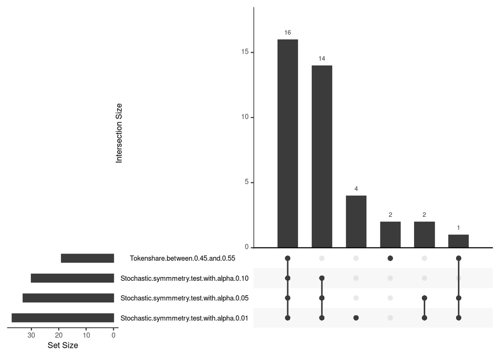

```r
classifications <- all |>
  select(c("impartial05", "stochastic_symmetricd01", "stochastic_symmetricd05", "stochastic_symmetricd10")) |>
  rename(`Tokenshare between 0.45 and 0.55` = impartial05,
         "Stochastic symmmetry test with alpha=0.01" = stochastic_symmetricd01,
          "Stochastic symmmetry test with alpha=0.05" = stochastic_symmetricd05,
          "Stochastic symmmetry test with alpha=0.10" = stochastic_symmetricd10) |>
  data.frame()
intersections <- UpSetR::upset(classifications, order.by="freq")
intersections
```